# 第2章 無作為化実験

[R2.3] 共変量の「統制」と回帰分析

作成者：川口康平

最終更新: 2024-09-15

ここでは、第2章の2.5節「共変量の『統制』と回帰分析」の手法を実装する。 `CausalInferenceTextbook`から呼び出している関数は`R/functions_randomized.R`に定義されている。まず標本の潜在結果を生成し、次に、処置ベクトルと顕在結果を生成する。その実現した処置ベクトルと顕在結果をもとに、回帰分析によって平均処置効果の推定量を得る。最後にその推定量の標準誤差を`sandwich`パッケージと手動計算の両方の方法で求める。

# 1 シミュレーションデータの生成

## 1.1 定数とパラメータの設定

はじめに、シードを固定して、個体数`N`、処置群のサイズ`N_1`を設定する。

```r
set.seed(1)
N <- 10000
N_1 <- 5000
```

つぎに、母集団における平均処置効果`tau_population`を設定する。

```r
tau_population <- 0.2
```

## 1.2 データの生成

以上の定数とパラメーターを元に標本の潜在結果を生成する。この操作が一回の無作為抽出にあたる。ただし、今回は個体ごとの共変量`x`を標準正規分布から生成する。そして、処置がないときの潜在結果が$Y_0^\ast(0) = \exp(x) - exp(1/2)$のように`x`に非線形に依存すると仮定する。このとき$\mathbb{E}\{Y_0^\ast(0)\} = 0$であり、母集団における平均処置効果は`tau_population`のままであることに注意せよ。無作為抽出された標本における平均処置効果`tau`も計算する。

```r
outcome_potential <-
  tibble::tibble(
    x = rnorm(N),
    y_0 =
      rnorm(
        N,
        mean =
          (
            exp(x) -
            exp(1/2)
          ),
        sd = 1
      ),
    y_1 =
      rnorm(
        N,
        mean = tau_population,
        sd = 1
      )
  )
tau <-
  outcome_potential %>%
  dplyr::summarise(
    tau = mean(
      y_1 -
      y_0
    )
  ) %>%
  dplyr::pull(tau)

outcome_potential %>%
  head() %>%
  kbl() %>%
  kable_styling()
```

| x | y_0 | y_1 |
| --- | --- | --- |
| -0.6264538 | -1.9185690 | 0.4353485 |
| 0.1836433 | -1.5036598 | 0.4448250 |
| -0.8356286 | -2.2505152 | -0.4421869 |
| 1.5952808 | 2.0954315 | -1.7348085 |
| 0.3295078 | -0.7588772 | 1.2386957 |
| -0.8204684 | -1.7334846 | -0.0835501 |

```r
outcome_potential %>%
  modelsummary::datasummary_skim()
```

Unique

Missing Pct.

Mean

SD

Min

Median

Max

Histogram

x

10000

0

0.0

1.0

-3.7

0.0

3.8

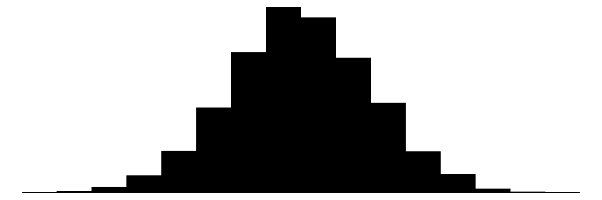

y_0

10000

0

0.0

2.3

-5.6

-0.4

44.8

[figure not shown]

y_1

10000

0

0.2

1.0

-3.4

0.2

3.9

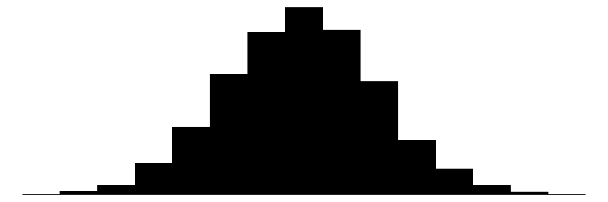

```r
tau
```

```
## [1] 0.2125288
```

次に、観察されるデータを生成する。そのために、まず処置ベクトル`z`を生成する。この操作が一回の無作為化実験にあたる。さらに、実現した処置ベクトルと潜在結果から、顕在結果を計算する。

```r
data_realized <-
  generate_data_randomized(
    outcome_potential = outcome_potential,
    N_1 = N_1,
    seed = 1
  )
data_realized %>%
  head() %>%
  kbl() %>%
  kable_styling()
```

| x | z | y |
| --- | --- | --- |
| -0.6264538 | 0 | -1.9185690 |
| 0.1836433 | 0 | -1.5036598 |
| -0.8356286 | 0 | -2.2505152 |
| 1.5952808 | 1 | -1.7348085 |
| 0.3295078 | 0 | -0.7588772 |
| -0.8204684 | 1 | -0.0835501 |

```r
data_realized %>%
  modelsummary::datasummary_skim()
```

Unique

Missing Pct.

Mean

SD

Min

Median

Max

Histogram

x

10000

0

0.0

1.0

-3.7

0.0

3.8

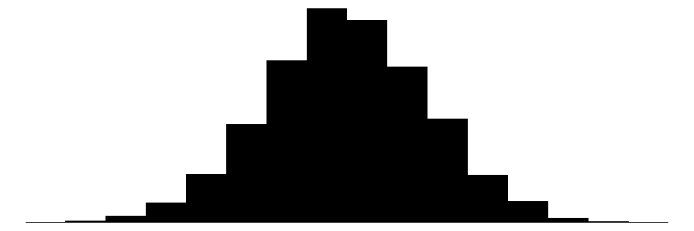

z

2

0

0.5

0.5

0.0

0.5

1.0

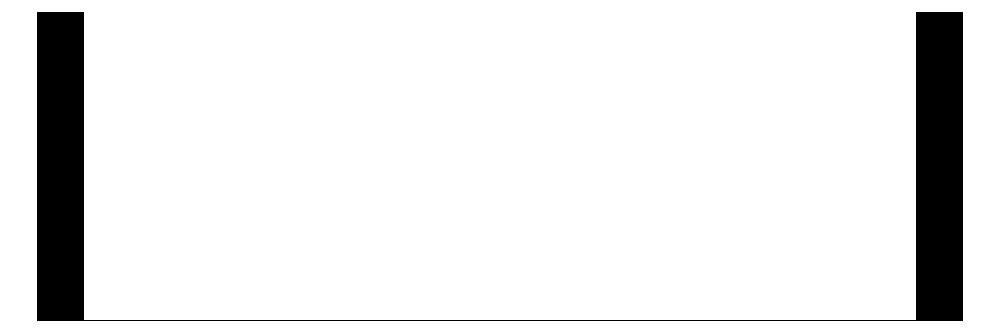

y

10000

0

0.1

1.8

-4.3

0.0

44.8

[figure not shown]

# 2 分析

## 2.1 回帰分析

以上のデータをもとに、回帰分析を行う。一つ目の定式化では共変量の情報を無視する。次に、`x`に関して線形な、正しく定式化されていないモデルを考える。

```r
result_ols <-
  c(
    "y ~ z",
    "y ~ z + x",
    "y ~ z + exp(x)",
    "y ~ z + x_dot + z:x_dot"
  ) %>%
  purrr::map(as.formula) %>%
  purrr::map(
    .,
    ~ lm(
      formula = .,
      data =
        data_realized %>%
        dplyr::mutate(
          x_dot = exp(x) - exp(1/2)
        )
      )
  )
```

## 2.2 推定結果

共変量の定式化の正しさによらず、標本の平均処置効果`tau` $=$ 0.2125288は95%信頼区間に含まれていることがわかる。

```r
result_ols %>%
  modelsummary(
    vcov = "HC2"
  )
```

|  | (1) | (2) | (3) | (4) |
| --- | --- | --- | --- | --- |
| (Intercept) | 0.037 | 0.026 | -0.868 | -0.007 |
|  | (0.034) | (0.027) | (0.060) | (0.014) |
| z | 0.174 | 0.208 | 0.222 | 0.218 |
|  | (0.037) | (0.032) | (0.029) | (0.020) |
| x |  | 0.842 |  |  |
|  |  | (0.033) |  |  |
| exp(x) |  |  | 0.535 |  |
|  |  |  | (0.038) |  |
| x_dot |  |  |  | 1.008 |
|  |  |  |  | (0.006) |
| z × x_dot |  |  |  | -1.011 |
|  |  |  |  | (0.009) |
| Num.Obs. | 10000 | 10000 | 10000 | 10000 |
| R2 | 0.002 | 0.216 | 0.374 | 0.704 |
| R2 Adj. | 0.002 | 0.216 | 0.374 | 0.704 |
| AIC | 40591.3 | 38184.5 | 35933.8 | 28430.7 |
| BIC | 40612.9 | 38213.3 | 35962.6 | 28466.8 |
| Log.Lik. | -20292.642 | -19088.235 | -17962.897 | -14210.364 |
| F | 22.334 | 624.737 | 118.577 | 8871.031 |
| RMSE | 1.84 | 1.63 | 1.46 | 1.00 |
| Std.Errors | HC2 | HC2 | HC2 | HC2 |

## 2.3 標準誤差の手動計算

```r
se_hetero <-
  result_ols %>%
  purrr::map(
    .,
    ~ data.frame(
      data_realized,
      residual = .$residuals,
      df = .$df.residual
      ) %>%
      dplyr::mutate(
        z_bar = mean(z)
      ) %>%
      dplyr::summarise(
        v =
          sum(
            (
              z - z_bar
            )^2 *
            residual^2 /
            (
              z_bar *
              (1 - z_bar)
            )^2
            )
        /
        (
          length(z) *
          mean(df)
        )
      ) %>%
      dplyr::ungroup() %>%
      sqrt()
  ) %>%
  dplyr::bind_rows()
```

```r
data.frame(
  model = c("共変量なし", "線形共変量", "指数共変量", "正しい定式化"),
  "不均一分散頑健分散推定量" = se_hetero$v
  ) %>%
  kbl() %>%
  kable_styling()
```

| model | 不均一分散頑健分散推定量 |
| --- | --- |
| 共変量なし | 0.0368243 |
| 線形共変量 | 0.0326475 |
| 指数共変量 | 0.0291727 |
| 正しい定式化 | 0.0200460 |